# Propser Loan Data Analysis

## Introduction

#### Who's Prosper?

> Marketplace is America's first peer-to-peer lending marketplace, with over $7 billion in funded loans.

```python
# import all packages and set plots to be embedded inline
import numpy as np
import pandas as pd
import matplotlib.pyplot as plt
import seaborn as sb

%matplotlib inline
```

```python
import warnings
warnings.filterwarnings('ignore')
```

> Following we will load data and find the feature of the dataset and the describtions.

```python
# Loading the data into pandas dataframe
pld = pd.read_csv('prosperLoanData.csv')
pld.head()
```

|  | ListingKey | ListingNumber | ListingCreationDate | CreditGrade | Term | LoanStatus | ClosedDate | BorrowerAPR | BorrowerRate | LenderYield | ... | LP_ServiceFees | LP_CollectionFees | LP_GrossPrincipalLoss | LP_NetPrincipalLoss | LP_NonPrincipalRecoverypayments | PercentFunded | Recommendations | InvestmentFromFriendsCount | InvestmentFromFriendsAmount | Investors |
| --- | --- | --- | --- | --- | --- | --- | --- | --- | --- | --- | --- | --- | --- | --- | --- | --- | --- | --- | --- | --- | --- |
| 0 | 1021339766868145413AB3B | 193129 | 2007-08-26 19:09:29.263000000 | C | 36 | Completed | 2009-08-14 00:00:00 | 0.16516 | 0.1580 | 0.1380 | ... | -133.18 | 0.0 | 0.0 | 0.0 | 0.0 | 1.0 | 0 | 0 | 0.0 | 258 |
| 1 | 10273602499503308B223C1 | 1209647 | 2014-02-27 08:28:07.900000000 | NaN | 36 | Current | NaN | 0.12016 | 0.0920 | 0.0820 | ... | 0.00 | 0.0 | 0.0 | 0.0 | 0.0 | 1.0 | 0 | 0 | 0.0 | 1 |
| 2 | 0EE9337825851032864889A | 81716 | 2007-01-05 15:00:47.090000000 | HR | 36 | Completed | 2009-12-17 00:00:00 | 0.28269 | 0.2750 | 0.2400 | ... | -24.20 | 0.0 | 0.0 | 0.0 | 0.0 | 1.0 | 0 | 0 | 0.0 | 41 |
| 3 | 0EF5356002482715299901A | 658116 | 2012-10-22 11:02:35.010000000 | NaN | 36 | Current | NaN | 0.12528 | 0.0974 | 0.0874 | ... | -108.01 | 0.0 | 0.0 | 0.0 | 0.0 | 1.0 | 0 | 0 | 0.0 | 158 |
| 4 | 0F023589499656230C5E3E2 | 909464 | 2013-09-14 18:38:39.097000000 | NaN | 36 | Current | NaN | 0.24614 | 0.2085 | 0.1985 | ... | -60.27 | 0.0 | 0.0 | 0.0 | 0.0 | 1.0 | 0 | 0 | 0.0 | 20 |

5 rows × 81 columns

```python
pld.shape
```

```
(113937, 81)
```

```python
pld.info()
```

```
<class 'pandas.core.frame.DataFrame'>
RangeIndex: 113937 entries, 0 to 113936
Data columns (total 81 columns):
 #   Column                               Non-Null Count   Dtype
---  ------                               --------------   -----
 0   ListingKey                           113937 non-null  object
 1   ListingNumber                        113937 non-null  int64
 2   ListingCreationDate                  113937 non-null  object
 3   CreditGrade                          28953 non-null   object
 4   Term                                 113937 non-null  int64
 5   LoanStatus                           113937 non-null  object
 6   ClosedDate                           55089 non-null   object
 7   BorrowerAPR                          113912 non-null  float64
 8   BorrowerRate                         113937 non-null  float64
 9   LenderYield                          113937 non-null  float64
```

[output cut: 73 more lines]

```python
pld.describe()
```

|  | ListingNumber | Term | BorrowerAPR | BorrowerRate | LenderYield | EstimatedEffectiveYield | EstimatedLoss | EstimatedReturn | ProsperRating (numeric) | ProsperScore | ... | LP_ServiceFees | LP_CollectionFees | LP_GrossPrincipalLoss | LP_NetPrincipalLoss | LP_NonPrincipalRecoverypayments | PercentFunded | Recommendations | InvestmentFromFriendsCount | InvestmentFromFriendsAmount | Investors |
| --- | --- | --- | --- | --- | --- | --- | --- | --- | --- | --- | --- | --- | --- | --- | --- | --- | --- | --- | --- | --- | --- |
| count | 1.139370e+05 | 113937.000000 | 113912.000000 | 113937.000000 | 113937.000000 | 84853.000000 | 84853.000000 | 84853.000000 | 84853.000000 | 84853.000000 | ... | 113937.000000 | 113937.000000 | 113937.000000 | 113937.000000 | 113937.000000 | 113937.000000 | 113937.000000 | 113937.000000 | 113937.000000 | 113937.000000 |
| mean | 6.278857e+05 | 40.830248 | 0.218828 | 0.192764 | 0.182701 | 0.168661 | 0.080306 | 0.096068 | 4.072243 | 5.950067 | ... | -54.725641 | -14.242698 | 700.446342 | 681.420499 | 25.142686 | 0.998584 | 0.048027 | 0.023460 | 16.550751 | 80.475228 |
| std | 3.280762e+05 | 10.436212 | 0.080364 | 0.074818 | 0.074516 | 0.068467 | 0.046764 | 0.030403 | 1.673227 | 2.376501 | ... | 60.675425 | 109.232758 | 2388.513831 | 2357.167068 | 275.657937 | 0.017919 | 0.332353 | 0.232412 | 294.545422 | 103.239020 |
| min | 4.000000e+00 | 12.000000 | 0.006530 | 0.000000 | -0.010000 | -0.182700 | 0.004900 | -0.182700 | 1.000000 | 1.000000 | ... | -664.870000 | -9274.750000 | -94.200000 | -954.550000 | 0.000000 | 0.700000 | 0.000000 | 0.000000 | 0.000000 | 1.000000 |
| 25% | 4.009190e+05 | 36.000000 | 0.156290 | 0.134000 | 0.124200 | 0.115670 | 0.042400 | 0.074080 | 3.000000 | 4.000000 | ... | -73.180000 | 0.000000 | 0.000000 | 0.000000 | 0.000000 | 1.000000 | 0.000000 | 0.000000 | 0.000000 | 2.000000 |
| 50% | 6.005540e+05 | 36.000000 | 0.209760 | 0.184000 | 0.173000 | 0.161500 | 0.072400 | 0.091700 | 4.000000 | 6.000000 | ... | -34.440000 | 0.000000 | 0.000000 | 0.000000 | 0.000000 | 1.000000 | 0.000000 | 0.000000 | 0.000000 | 44.000000 |
| 75% | 8.926340e+05 | 36.000000 | 0.283810 | 0.250000 | 0.240000 | 0.224300 | 0.112000 | 0.116600 | 5.000000 | 8.000000 | ... | -13.920000 | 0.000000 | 0.000000 | 0.000000 | 0.000000 | 1.000000 | 0.000000 | 0.000000 | 0.000000 | 115.000000 |
| max | 1.255725e+06 | 60.000000 | 0.512290 | 0.497500 | 0.492500 | 0.319900 | 0.366000 | 0.283700 | 7.000000 | 11.000000 | ... | 32.060000 | 0.000000 | 25000.000000 | 25000.000000 | 21117.900000 | 1.012500 | 39.000000 | 33.000000 | 25000.000000 | 1189.000000 |

8 rows × 61 columns

```python
pd.set_option('display.max_rows',None)
```

```python
pld.isna().sum()
```

```
ListingKey                                  0
ListingNumber                               0
ListingCreationDate                         0
CreditGrade                             84984
Term                                        0
LoanStatus                                  0
ClosedDate                              58848
BorrowerAPR                                25
BorrowerRate                                0
LenderYield                                 0
EstimatedEffectiveYield                 29084
EstimatedLoss                           29084
EstimatedReturn                         29084
ProsperRating (numeric)                 29084
ProsperRating (Alpha)                   29084
ProsperScore                            29084
ListingCategory (numeric)                   0
BorrowerState                            5515
Occupation                               3588
EmploymentStatus                         2255
EmploymentStatusDuration                 7625
IsBorrowerHomeowner                         0
CurrentlyInGroup                            0
GroupKey                               100596
DateCreditPulled                            0
CreditScoreRangeLower                     591
CreditScoreRangeUpper                     591
FirstRecordedCreditLine                   697
CurrentCreditLines                       7604
OpenCreditLines                          7604
TotalCreditLinespast7years                697
OpenRevolvingAccounts                       0
OpenRevolvingMonthlyPayment                 0
InquiriesLast6Months                      697
TotalInquiries                           1159
CurrentDelinquencies                      697
AmountDelinquent                         7622
DelinquenciesLast7Years                   990
PublicRecordsLast10Years                  697
PublicRecordsLast12Months                7604
```

[output cut: 27 more lines]

```
MonthlyLoanPayment                          0
LP_CustomerPayments                         0
LP_CustomerPrincipalPayments                0
LP_InterestandFees                          0
LP_ServiceFees                              0
LP_CollectionFees                           0
LP_GrossPrincipalLoss                       0
LP_NetPrincipalLoss                         0
LP_NonPrincipalRecoverypayments             0
PercentFunded                               0
Recommendations                             0
InvestmentFromFriendsCount                  0
InvestmentFromFriendsAmount                 0
Investors                                   0
dtype: int64
```

```python
pld.CreditGrade.unique()
```

```
array(['C', nan, 'HR', 'AA', 'D', 'B', 'E', 'A', 'NC'], dtype=object)
```

```python
pld.CreditGrade.value_counts()
```

```
C     5649
D     5153
B     4389
AA    3509
HR    3508
A     3315
E     3289
NC     141
Name: CreditGrade, dtype: int64
```

### What is the structure of your dataset?

This data set contains 113,937 loans with 81 variables on each loan, including loan amount, borrower rate (or interest rate), current loan status, borrower income, and many others. The data contains numeric and categorical.

### What is/are the main feature(s) of interest in your dataset?

> This dataset contains 81 different variable for different findings

Main figurings to find out

- What's income level for the borrowers?
- Does Estimated Return varies from the BorrowerAPR?
- What's the borrowers Credit Score?
- Does Credit Score and Credit Rating influence the borrowers APR?
- Does borrower Income has influence?
- What are the Credit rating for Homeowner borrowers?
- Does Lenders prefer borrowers with better Prosper Score ?
- What's the relation between
  - Current and Completed Loans vs. Borrower Rate
  - Homeowner vs. Credit Rating
  - Income Range vs. Borrowers Rating
  - Credit Grades vs. BorrowerRate
  - Income Range vs. CreditScoreAve
  - Prosper Score vs. Credit Score Ave
  - Credit Rating vs. Income Range
  - Average Credit Score vs. BorrowerAPR
  - 'BorrowerAPR', 'ProsporScore' vs 'EstimatedReturn'
  - Relation between Borrowers Rate and Credit Rating during the Years
  - Average Credit Score vs. Borrower APR vs. Loan Term
  - Estimated Loss vs BorrowerAPR

### What features in the dataset do you think will help support your investigation into your feature(s) of interest?

This dataset have so much to explore:

- 1- **IncomeRange** divided income classes
- 2- **BorrowerAPR** Borrower annual interest rate
- 3- **BorrowerRate**: The Borrower's interest rate for the current loan.
- 4- **CreditGrade**: Credit Ranks
- 5- **ProsperRating** : Borrower Ranks at Prosper
- 6- **EstimatedReturn**: Annual Estimated interest rate
- 7- **Year** Loans Year
- 8- **LoanStatus**: status of the loans
- 9- **CreditScoreAve**: the average between the 'CreditScoreRangeLower', 'CreditScoreRangeUpper'.
- 10- **EstimatedEffectiveYield**: the return on loans that has its interest payments
- 11- **IsBorrowerHomeowner**: If the Borrower own a home and posibility of mortgage
- 12- **Term** Loan term by months
- 13- **Estimated Loss**

## Univariate Exploration

### `Group Key`

```python
# Checking the null values in Group Key
pld.GroupKey.isnull().sum()
```

```
100596
```

### `Term`

```python
pld.Term.value_counts()
```

```
36    87778
60    24545
12     1614
Name: Term, dtype: int64
```

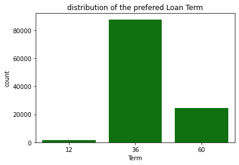

```python
#plot the distribution of the prefered Loan Term
sb.countplot(pld.Term, color = "green")
plt.title('distribution of the prefered Loan Term');
```

We see here that '87778' borrower, magority of the borrowers, admitted to a 3 years Term loan more than any other plans.

## `Is Borrower Home owner`

```python
pld.IsBorrowerHomeowner.value_counts()
```

```
True     57478
False    56459
Name: IsBorrowerHomeowner, dtype: int64
```

```python
pld['IsBorrowerHomeowner'] = pld['IsBorrowerHomeowner'].astype('int64')
```

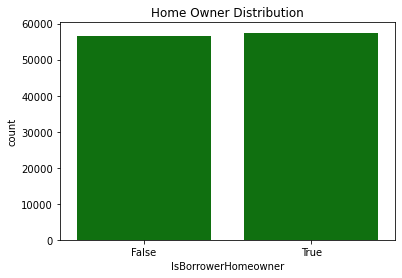

```python
#Distribution plot
sb.countplot(pld.IsBorrowerHomeowner, color = "Green")
plt.title("Home Owner Distribution");
```

We see that almost half of the borrowers are homeowner and there is a high possibility they use the loans paying for their home mortgage

## Year of Loans

```python
pld['YearD'] = pd.to_datetime(pld['LoanOriginationDate']).dt.year
```

```python
pld['Year'] = pld['LoanOriginationQuarter'].map(lambda x: x.lstrip('+-').rstrip('aAbBcC'))
pld['Year'] =pld.Year.str[3:].fillna(0).astype('int64')
```

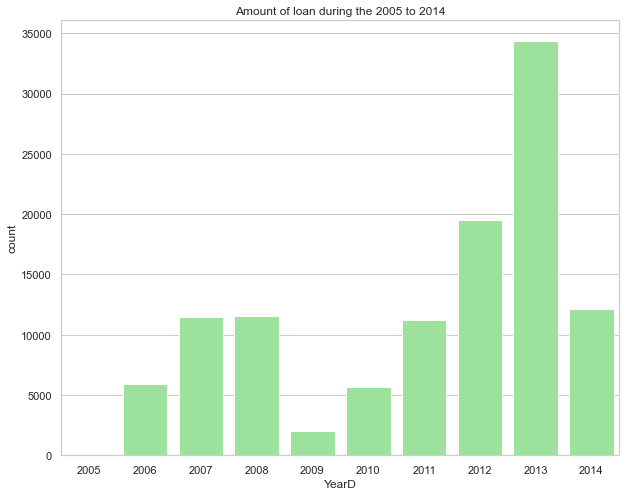

```python
#plot Amount of loan during the 2005 to 2014
plt.figure(figsize = (10,8))
sb.countplot(data = pld, x = 'YearD', color = 'lightgreen')
plt.title("Amount of loan during the 2005 to 2014");
```

### `Estimated Return`

Exploring the column variables and features.

```python
pld.EstimatedReturn.describe()
```

```
count    84853.000000
mean         0.096068
std          0.030403
min         -0.182700
25%          0.074080
50%          0.091700
75%          0.116600
max          0.283700
Name: EstimatedReturn, dtype: float64
```

```python
# dropping the null value
pld.EstimatedReturn.dropna(axis = 0, inplace = True)
```

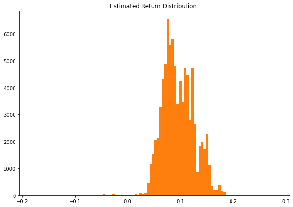

```python
# plotting Estimated Return
plt.figure(figsize = [10, 7])
colorbase= sb.color_palette()[1]

plt.hist( pld.EstimatedReturn, color = colorbase, bins = 100)
plt.title("Estimated Return Distribution ");
```

Estimated Return plot showing alot of outliers so will take closer look at the volumn range ( 0 , 0.2)

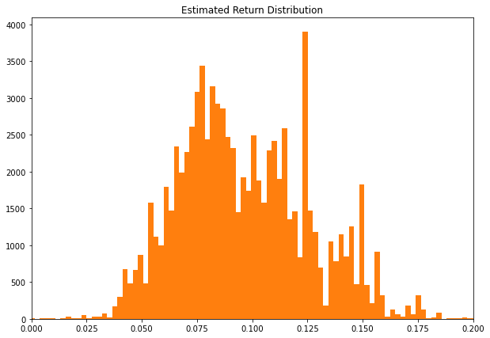

```python
#exploring (0, 0.2) range in theEstimatedReturn
plt.figure(figsize = [10,7])
plt.hist( pld.EstimatedReturn, color = colorbase, bins = 200)
plt.xlim(0, 0.2)
plt.title('Estimated Return Distribution');
```

We see the peaks for the Estimated Return are moslty in level of 7.5% and the largest estimation at 12.5%.

We now can take a look at the actual return and see the difference!

## Borrower Rate:

The Borrower's interest rate for this loan.

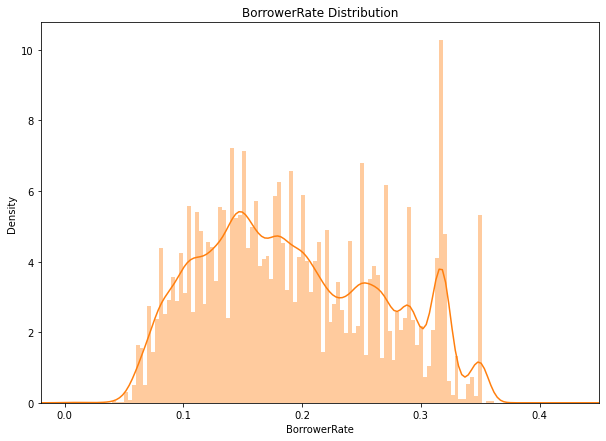

```python
plt.figure(figsize = [10,7])
sb.distplot( pld ['BorrowerRate'] , color = colorbase, bins = 150)
plt.title('BorrowerRate Distribution')
plt.xlim(-0.02, 0.45);
```

We see a not much of wide range of the Borrower Rate values. The highest spike shows that borrower. The distribution is right skewed which might refer that borrower rate decreases whenever. However, we see that most of the loans returns interest rate falls in range of 10% interest to 25% from the original loan amount, which is a good but not as the Estimated Returns!

### `Loan Status`

By plotting the loan status we can see what's different between loan status and actual returns. As documentations shows that loan status contains different status of 'Current', 'Completed', 'Chargedoff', 'Defaulted.

```python
pld.LoanStatus.unique()
```

```
array(['Completed', 'Current', 'Past Due (1-15 days)', 'Defaulted',
       'Chargedoff', 'Past Due (16-30 days)', 'Cancelled',
       'Past Due (61-90 days)', 'Past Due (31-60 days)',
       'Past Due (91-120 days)', 'FinalPaymentInProgress',
       'Past Due (>120 days)'], dtype=object)
```

```python
status_count = pld.LoanStatus.value_counts()
status_count
```

```
Current                   56576
Completed                 38074
Chargedoff                11992
Defaulted                  5018
Past Due (1-15 days)        806
Past Due (31-60 days)       363
Past Due (61-90 days)       313
Past Due (91-120 days)      304
Past Due (16-30 days)       265
FinalPaymentInProgress      205
Past Due (>120 days)         16
Cancelled                     5
Name: LoanStatus, dtype: int64
```

```python
n_status= pld.LoanStatus.value_counts().sum()
n_status
```

```
113937
```

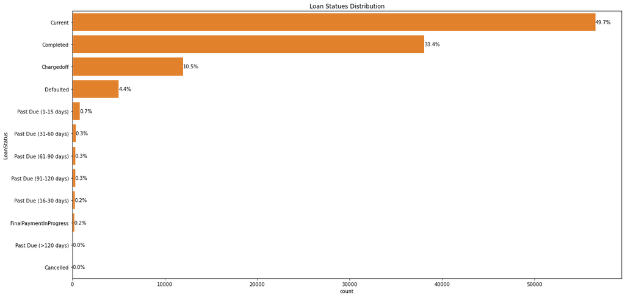

```python
#plot Loan Status and removing the noise variables.
plt.figure(figsize = [20,10])

status_order = pld['LoanStatus'].value_counts().index

sb.countplot(data = pld, y = 'LoanStatus', color= colorbase, order = status_order)

#Adding percentage to each status column

for i in range(status_count.shape[0]):
    count = status_count[i]
    pct_status= '{:0.1f}%'.format(100*count/n_status)
    plt.text( count+1, i, pct_status, va='center', color = "black")
#plt.xticks(rotation = 90);
plt.title(' Loan Statues Distribution ');
```

This Distribution shows that out of 12 different loan statues there are only 4 stands out, Current with 49.7% of borrowers, Completed 33.4%, Chargedoff, and Defaulted.

### `Propser Credit Rate & Credit Grades`

The Prosper Rating assigned at the time the listing was created between AA - HR. Applicable for loans originated after July 2009.

As for the **`Credit Grade`** is Credit rating that was assigned in tome of the application

So the idea here is to combine both into one variable column, as they are compeleting each other.

```python
pld['ProsperRating (Alpha)'].unique()
```

```
array([nan, 'A', 'D', 'B', 'E', 'C', 'AA', 'HR'], dtype=object)
```

```python
pld['ProsperRating (Alpha)'].describe()
```

```
count     84853
unique        7
top           C
freq      18345
Name: ProsperRating (Alpha), dtype: object
```

```python
pld['ProsperRating (Alpha)'].value_counts()
```

```
C     18345
B     15581
A     14551
D     14274
E      9795
HR     6935
AA     5372
Name: ProsperRating (Alpha), dtype: int64
```

```python
#rename column for short
pld = pld.rename({'ProsperRating (Alpha)':'ProsperRating'}, axis=1)
```

```python
#Clean CreditGrade
pld['CreditGrade'].replace('NC', 'HR', inplace = True)

# fill what left of nan with empty space to make the merge
pld['ProsperRating'].fillna('', inplace = True)
pld['CreditGrade'].fillna('', inplace = True)
```

```python
pld['CreditGrade'].describe(), pld['CreditGrade'].unique()
```

```
(count     113937
 unique         8
 top
 freq       84984
 Name: CreditGrade, dtype: object,
 array(['C', '', 'HR', 'AA', 'D', 'B', 'E', 'A'], dtype=object))
```

```python
# as credit rating column for data before 2009 and prosper rating for data after 2009 so will merge them
pld['CreditGrade'] = pld['ProsperRating'] + pld['CreditGrade']
pld['CreditGrade'].unique()
```

```
array(['C', 'A', 'HR', 'D', 'B', 'E', 'AA', ''], dtype=object)
```

```python
pld['CreditGrade'].replace('', 'HR', inplace = True)
```

```python
pld['CreditGrade'].unique()
```

```
array(['C', 'A', 'HR', 'D', 'B', 'E', 'AA'], dtype=object)
```

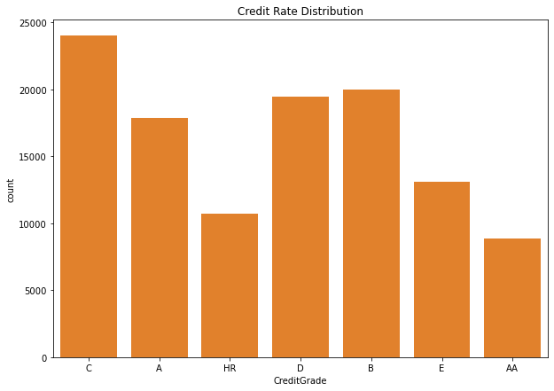

```python
plt.figure(figsize = [10,7])
sb.countplot(data = pld, x = 'CreditGrade' , color = colorbase)
plt.title('Credit Rate Distribution');
```

We understand Credit Grade has 'NC' variable which is stands for 'No Credit', so we can move it to be 'HR' High Risk

```python
pld['CreditGrade'].isna().sum()
```

```
0
```

```python
pld['CreditGrade'].unique()
```

```
array(['C', 'A', 'HR', 'D', 'B', 'E', 'AA'], dtype=object)
```

```python
# change credit rating column from int64 type to categorcial type
Rating_Level = ['AA', 'A', 'B', 'C', 'D', 'E','HR']
Rating_order = pd.api.types.CategoricalDtype(ordered = True, categories = Rating_Level)
pld['CreditGrade'] = pld['CreditGrade'].astype(Rating_order)
```

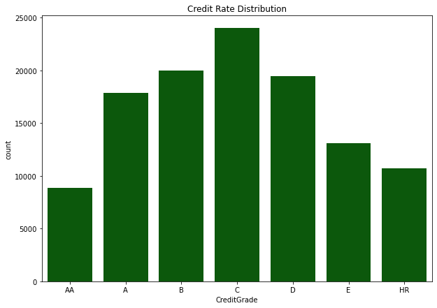

```python
#plotting Credit Rating

plt.figure(figsize = [10,7])
sb.countplot(data = pld, x = 'CreditGrade' , color = "darkgreen")
plt.title('Credit Rate Distribution');
```

Credit Rating figure is right skewed same as the Estimated Return. Rating "C" is the highest Borrowers Credit Ratings.

### `Income Range`

Income Range is one of the Borrowers feature in determind in the Credit Rating of the borrowers.

```python
pld.IncomeRange.value_counts()
```

```
$25,000-49,999    32192
$50,000-74,999    31050
$100,000+         17337
$75,000-99,999    16916
Not displayed      7741
$1-24,999          7274
Not employed        806
$0                  621
Name: IncomeRange, dtype: int64
```

```python
pld['IncomeRange'].replace(['Not employed', 'Not displayed'], '$0', inplace = True)
```

```python
#change Income Range column from int64 type to categorcial type
Income_level = ['$100,000+', '$75,000-99,999', '$50,000-74,999', '$25,000-49,999', '$1-24,999', '$0']
Income_order = pd.api.types.CategoricalDtype(ordered = True, categories = Income_level)
pld['IncomeRange'] = pld['IncomeRange'].astype(Income_order)
```

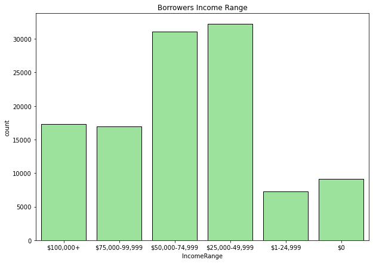

```python
#plotting Income Range chart
plt.figure(figsize = [10, 7])
sb.countplot(data = pld, x = 'IncomeRange', color = 'lightgreen', edgecolor = 'black')
plt.title('Borrowers Income Range');
```

We can interpreter that most of the borrower are from the middle class community in the US.

## Prosper Score

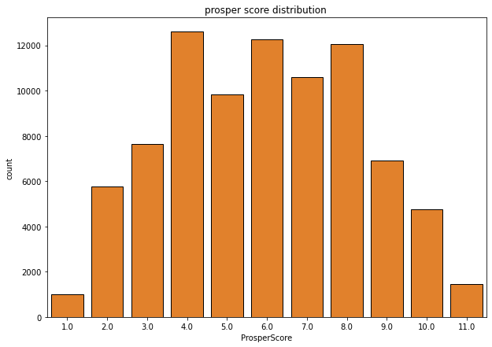

```python
#plotting the prosper score distribution
plt.figure(figsize = [10, 7])
sb.countplot(pld['ProsperScore'], color = colorbase, edgecolor ='black')
plt.title ('prosper score distribution ');
```

### `Debt to Income Ratio`

Another variable plays in determining the borrowers rate in the (debt/income) Ratio. The investors want to be sure that the borrower are able to repay their debt in case they lost their income.

```python
pld.DebtToIncomeRatio.describe()
```

```
count    105383.000000
mean          0.275947
std           0.551759
min           0.000000
25%           0.140000
50%           0.220000
75%           0.320000
max          10.010000
Name: DebtToIncomeRatio, dtype: float64
```

> The average of DTI for the Borrowers is about 27% and about 75% of the borrowers don'e exceed the DTI 32%

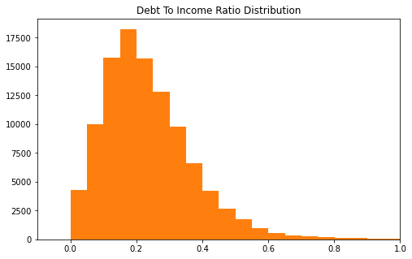

```python
# Plot chart for DTI
plt.figure(figsize = [ 8,5])
plt.hist(pld.DebtToIncomeRatio,  bins = 200, color = colorbase)
plt.xlim(-0.1, 1)
plt.title('Debt To Income Ratio Distribution');
```

Chart shows that most of the borrowers' Debt to Income Ratio is fall in the accceptable range which is not more than 38% according to the best case scenaro ["28/36 rule"](https://www.investopedia.com/terms/t/twenty-eight-thirty-six-rule.asp) as it's good ration if the borrowers' DTI is between 28% and max 36% including the debts payment and rents.

### `Credit Score Average`

We will take the average between 'CreditScoreRangeLower'and 'CreditScoreRangeUpper'to reduce the calculation for efficieny

```python
#merging both credit score columns to analysis
pld['CreditScoreAve']= pld[['CreditScoreRangeLower', 'CreditScoreRangeUpper']].mean(axis=1)
```

```python
pld['CreditScoreAve'].describe()
```

```
count    113346.000000
mean        695.067731
std          66.458275
min           9.500000
25%         669.500000
50%         689.500000
75%         729.500000
max         889.500000
Name: CreditScoreAve, dtype: float64
```

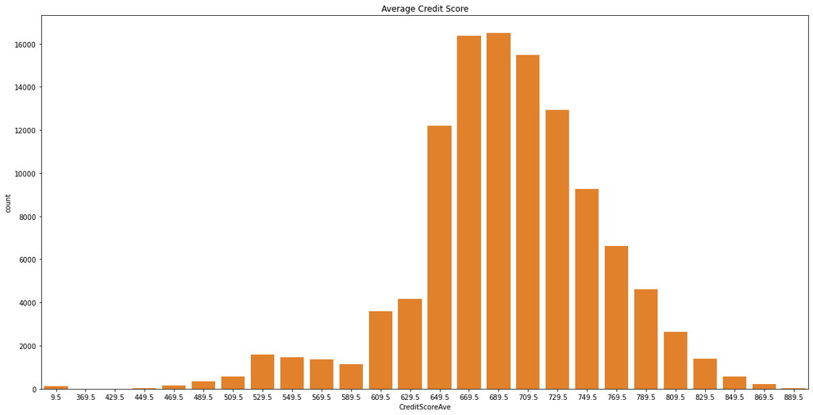

```python
#ploting Average Credit score
plt.figure(figsize = (20,10))
sb.countplot(data = pld, x = 'CreditScoreAve', color = colorbase)
plt.title("Average Credit Score");
```

Here we see a left skewed chart, most of the borrowers score fall between the 650 and 750. According to [Equifax | Credit Bureau](https://www.equifax.com/personal/education/credit/score/what-is-a-good-credit-score/#:~:text=Although%20ranges%20vary%20depending%20on,and%20up%20are%20considered%20excellent.) that a Good Credit score is between 670 and 740, which shows that Prosper's borrower mostly in that range.

### Discuss the distribution(s) of your variable(s) of interest. Were there any unusual points? Did you need to perform any transformations?

> We were interested in those variable we looked at, Income Range, Debt to Income Ration, Prosper Rating,Credit Grade, Estimated Return, Loan Years, loans Terms, ProsperScore and Loan Status. There was a normal distribution at the Income Range and Debt to Income Ratio and right skewed distribution to Estimated Return and Loan Status.

> Side info : After the Securities and Exchange Commission made Prosper redo their Annual Return for miscalculating and materially overstating annualized net returns to retail and other investors.For almost two years, Prosper told tens of thousands of investors that their returns were higher than they actually were despite warning signs that should have alerted Prosper that it was miscalculating those returns. This is a very misleading facts from Prosper.

## Bivariate Exploration

> In this section, investigate relationships between pairs of variables in your data. Make sure the variables that you cover here have been introduced in some fashion in the previous section (univariate exploration).

### `Homeowner vs. Credit Rating`

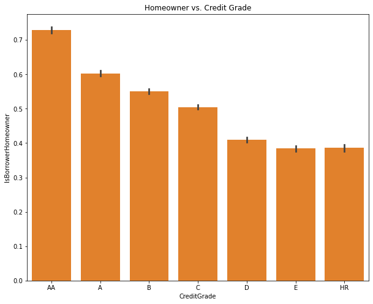

```python
#plot Homeowner vs. Credit Grade
plt.figure(figsize = (10,8))
sb.barplot(data = pld, x ='CreditGrade', y = 'IsBorrowerHomeowner', color = colorbase )
plt.title("Homeowner vs. Credit Grade");
```

We see that alot of homeowner borrowers have the Highest Credit Rank. As if you are a homeowner, the lender will give you a better interest rate as this consider the major reason for the borrowers to apply for loan. So lender might attract them with good rates. Also, we could see the chart as most of the Highest rank owning home, not renting which might refer to financial stability for the borrower to repay the loan.

## Current and Completed Loans vs. Borrower Rate

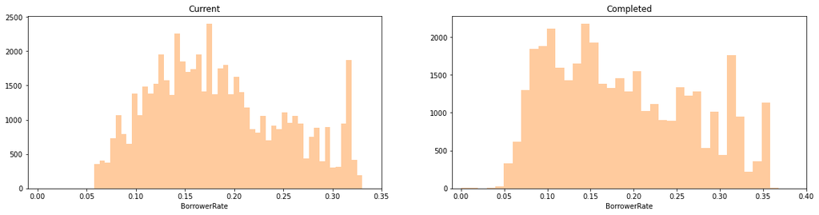

```python
#plotting Loan Status each status

Highstatus = ['Current', 'Completed']
plt.figure(figsize = [20, 10])
plt.title('Loan Status vs. Borrower Rate')
#looping the Highstatus
for i in range(len(Highstatus)):
    plt.subplot(2,2, i+1)

    sb.distplot(pld.query('LoanStatus == "{}"'.format(Highstatus[i])).BorrowerRate, kde = False, color= colorbase  )
    plt.title(Highstatus[i])
    plt.xlim(-0.01, 0.4)
plt.subplot(2,2,1)
plt.xlim(-0.01, 0.35);
```

In the status of Current Loans, appears that large numbers of loans have interest rate between 10% and 20%. We don't know if the Current status holds inside the new issued loans. The distribution is right skewed.

The status of completed loans, the plot show that borrower interest rate returns are in range of 10% to 25% of the total.

### `Income Range vs. Borrowers Rating`

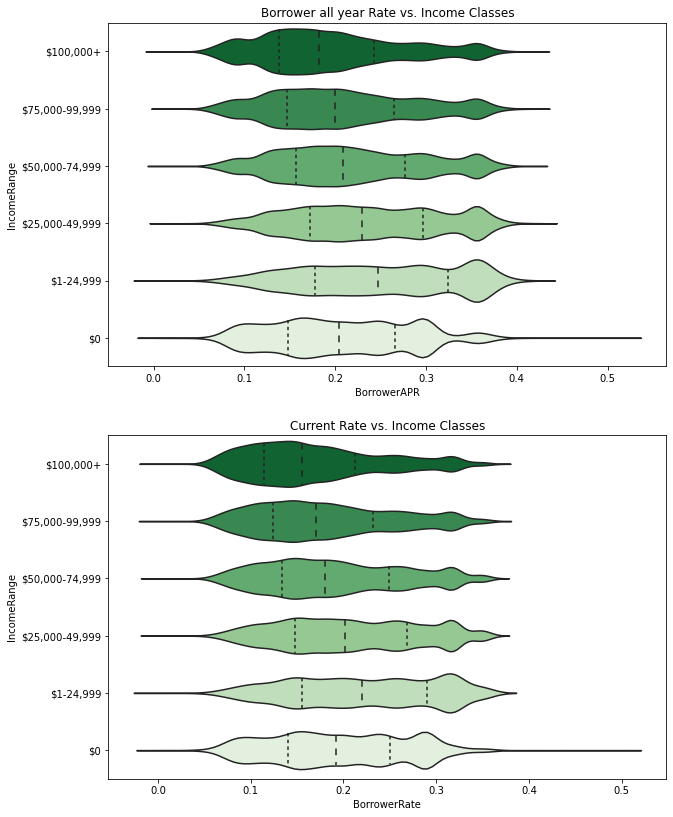

```python
# Violin ploting quantitative and qualitative variable
plt.figure(figsize = [10, 7])

plt.subplot(2,1,2)
sb.violinplot(data = pld, y = 'IncomeRange', x = 'BorrowerRate', palette = "Greens_r",  inner='quartile')
plt.title("Current Rate vs. Income Classes");

plt.subplot(2, 1, 1)
sb.violinplot(data = pld, y = 'IncomeRange', x = 'BorrowerAPR', palette = "Greens_r",  inner='quartile')
plt.title("Borrower all year Rate vs. Income Classes")

plt.subplots_adjust(top = 3.5, bottom = 2);
```

### `Credit Grades vs. BorrowerRate`

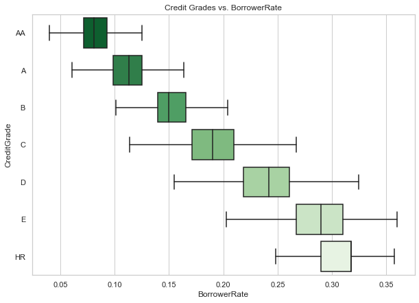

```python
# Box ploting quantitative and qualitative variable
plt.figure(figsize = [10, 7])
sb.boxplot(data = pld, y = 'CreditGrade', x = 'BorrowerRate', palette = "Greens_r", showfliers = False)
plt.title("Credit Grades vs. BorrowerRate");
```

In the boxplot chart when the Credit rate increase the median of the interest rate decreases, the median show negative trend

### `Income Range vs. CreditScoreAve`

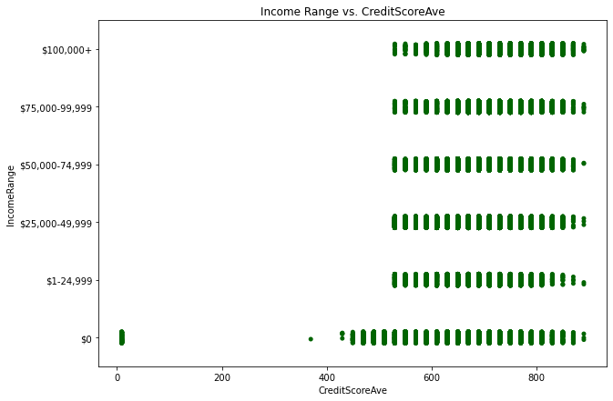

```python
plt.figure(figsize = [10, 7])

sb.stripplot(data = pld, y = 'IncomeRange', x = 'CreditScoreAve', color = 'darkgreen')
plt.title("Income Range vs. CreditScoreAve");
```

## `Prosper Score vs. Credit Score Ave`

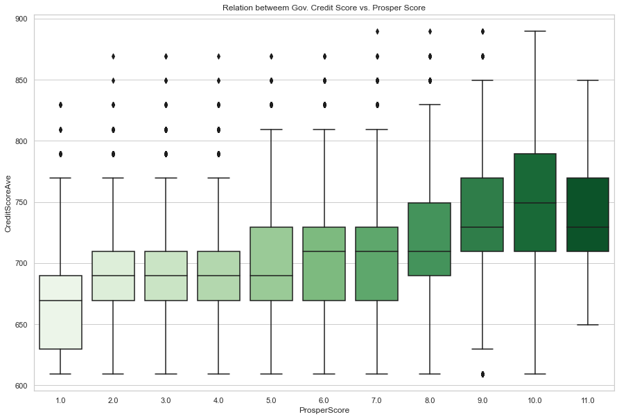

```python
plt.figure(figsize = [15,10])
sb.boxplot(x="ProsperScore", y="CreditScoreAve", data=pld, palette="Greens")
plt.title("Relation betweem Gov. Credit Score vs. Prosper Score");
```

The two rating system for credit score and prosper score same, however prosper has it's own way of measurement, that show a little bit of difference between both

### `Credit Rating vs. Income Range`

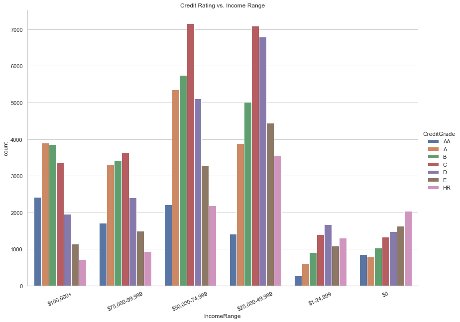

```python
### plotting cluster for Credit Rating vs. Income Range

sb.catplot(x="IncomeRange", hue="CreditGrade", kind="count",
            data=pld, height=8.27, aspect=11.7/8.27)
plt.xticks(rotation = 25)
plt.title ("Credit Rating vs. Income Range");
```

When we take a deep look at the Income range of $0, it shows that there might be some borrowers were able to recieve loans without income, which make us thing if there are other variable to grant non income borrowers to get loans.

### `Estimated Effective Yield vs Prosper Score` *

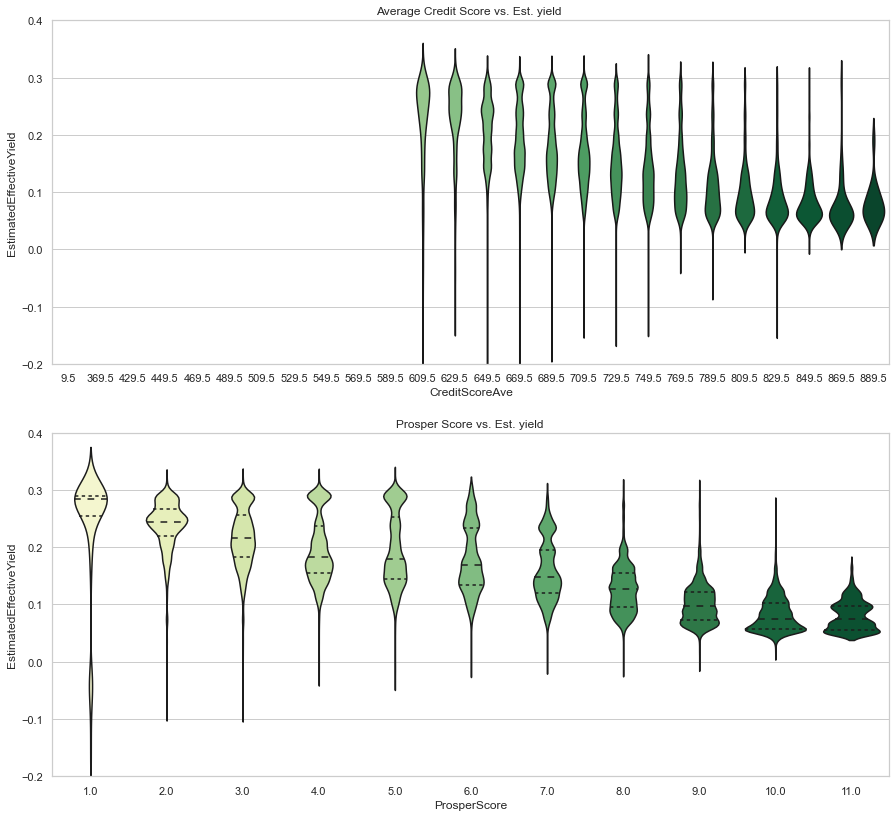

```python
# Violin ploting Prosper Score vs. Est. yield
plt.figure(figsize = [15, 7])

plt.subplot(2,1,2)
sb.set_theme(style="whitegrid")
sb.violinplot(data = pld, y = 'EstimatedEffectiveYield', x = 'ProsperScore', palette = 'YlGn', showfliers = False, inner= 'quartile')
plt.ylim([-0.2,0.4])
plt.title("Prosper Score vs. Est. yield ");


# Violin chart for EstimatedEffectiveYield vs. CreditScoreAve
plt.subplot(2, 1, 1)
#plt.figure(figsize = [20, 7])
sb.set_theme(style="whitegrid")
sb.violinplot(data = pld, y = 'EstimatedEffectiveYield', x = 'CreditScoreAve', palette = 'YlGn', showfliers = False, inner= None)
plt.ylim([-0.2,0.4])
plt.title("Average Credit Score vs. Est. yield ")

plt.subplots_adjust(top = 3.5, bottom = 2);
```

Prosper score shows a negative correlation with Estimated Yield. The median line represent the negative trend. The higher the prosper score the lower the interest yield that a lander would give for a borrower. We can see a lower prosper score volumn of yield much more than the volumn of the higher prosper score.

### `Average Credit Score vs. BorrowerAPR`*

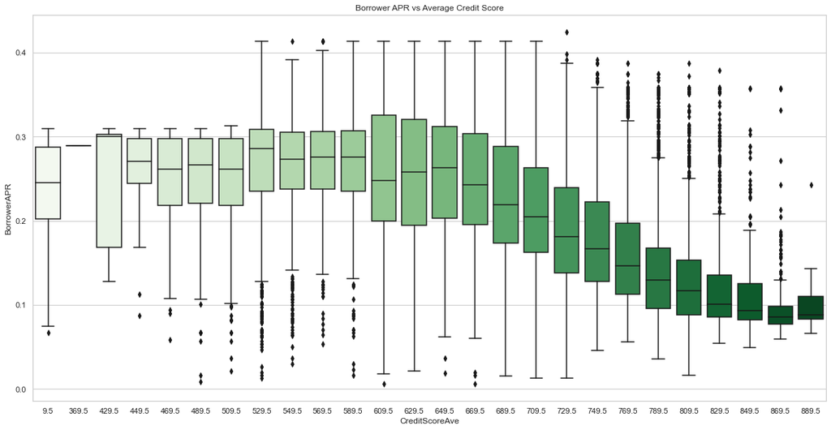

```python
ax = sb.boxplot(data = pld, x = 'CreditScoreAve', y = 'BorrowerAPR', palette="Greens")
plt.gcf().set_size_inches(20, 10)
plt.title('Borrower APR vs Average Credit Score');

ax.set_xticklabels([t.get_text()  for t in ax.get_xticklabels()]);
```

Here we found a negative relationship between average credit score and borrower APR. As when credit score increases, the estimated interest rate decreases. This reflect the risk of lending money, as investors would prefer to give better interest rate for borrowers who able to repay faster. We can see the negative trend from the median levels in the box plot.

## Multivariate Exploration

> Here will analyis couple of features together and find out the replation ship and if it draws different conclutions.

### `'BorrowerAPR', 'ProsporScore' vs 'EstimatedReturn'`

Here we see the correlation between those numeric and categorical variable:

```python
#Define the code variable
NumVar = ['BorrowerAPR', 'ProsporScore', 'EstimatedReturn']
```

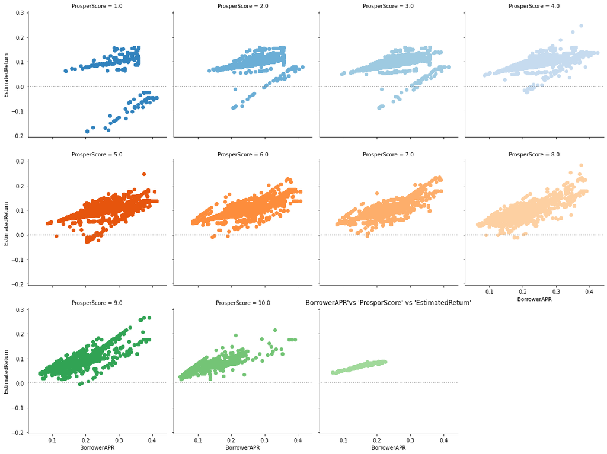

```python
# Initialize a grid of plots

plt.figure(figsize = [20, 10])
grid = sb.FacetGrid(pld, col="ProsperScore", hue="ProsperScore", palette="tab20c",
                     col_wrap=4, height=4)

# Draw a horizontal line to show the starting point
grid.map(plt.axhline, y=0, ls=":", c=".5")

# Draw a line plot to show the trajectory of Prospercore
grid.map(plt.scatter, "BorrowerAPR", "EstimatedReturn")


# Adjust the arrangement of the plots
grid.fig.tight_layout(w_pad=1)
plt.title("BorrowerAPR'vs 'ProsporScore' vs 'EstimatedReturn'");
```

In the grid plot above we can see a corrilation between 'BorrowerAPR', 'ProsporScore', 'EstimatedReturn. As it shown it's positive trend We see a weak correlation between Estimated Returns and prosper Score , and that return to what we read that the Prosper miscalculating and materially overstating annualized net returns. If you notice the slop of the trend between the two rates we will see, the trend close to be horizontal at rate 1, 3, 4 and 11. We also see that the prosper score 6, 7, 8 consider the highest in interest rate in both estimated and current rate. As for the prosper score 11 gets the lowest score as the borrowers with high rank and lender offer them better interest rate deal.

### `Relationship Chart`

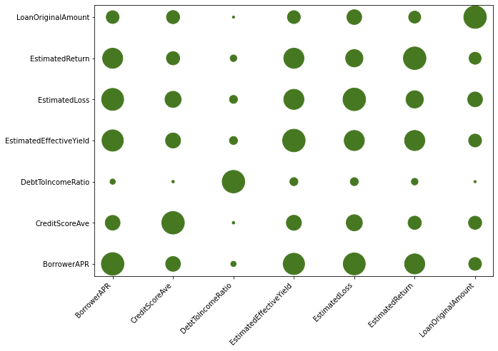

```python
plt.rcParams["figure.figsize"] = (10,7);

def heatmap(x, y, size):
    fig, ax = plt.subplots()

    # Mapping from column names to integer coordinates
    x_labels = [v for v in sorted(x.unique())]
    y_labels = [v for v in sorted(y.unique())]
    x_to_num = {p[1]:p[0] for p in enumerate(x_labels)}
    y_to_num = {p[1]:p[0] for p in enumerate(y_labels)}

    plt.figure(figsize=(8, 8), dpi=80)
    size_scale = 1000

    ax.scatter(
        x=x.map(x_to_num), # Use mapping for x
        y=y.map(y_to_num), # Use mapping for y
        s=size * size_scale, # Vector of square sizes, proportional to size parameter
        marker='o', # Use square as scatterplot marker
        c='#467821'
    )

    # Show column labels on the axes
    ax.set_xticks([x_to_num[v] for v in x_labels])
    ax.set_xticklabels(x_labels, rotation=45, horizontalalignment='right')
    ax.set_yticks([y_to_num[v] for v in y_labels])
    ax.set_yticklabels(y_labels);

data = pld
columns = [ 'EstimatedReturn', 'CreditScoreAve', 'DebtToIncomeRatio', 'EstimatedEffectiveYield','BorrowerAPR', 'LoanOriginalAmount','EstimatedLoss']
corr = data[columns].corr()
corr = pd.melt(corr.reset_index(), id_vars='index') # Unpivot the dataframe, so we can get pair of arrays for x and y
corr.columns = ['x', 'y', 'value']
heatmap(
    x=corr['x'],
    y=corr['y'],
    size=corr['value'].abs()
);
```

Also, the Estimated Loss has a positive relationship with BorrowerAPR, Estimated Yield. That lead Credit Score would really impact the Loan Amount, Yields, and Interest Rate.

## Relation between Borrowers Rate and Credit Rating during the Years

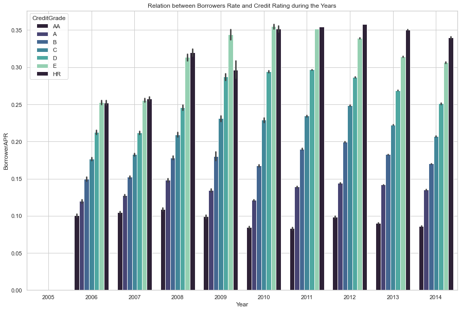

```python
# Some boilerplate to initialise things
#sb.set()
plt.figure(figsize = [15,10])
col = sb.color_palette("mako")
# This is where the actual plot gets made
ax = sb.barplot(data=pld, x="YearD", y="BorrowerAPR", hue="CreditGrade", palette=col)

# Customise some display properties
ax.set_title('Relation between Borrowers Rate and Credit Rating during the Years')
ax.grid(color='#cccccc')
ax.set_ylabel('BorrowerAPR')
ax.set_xlabel('Year')



def Q(n):
    num_Y = len(YearD())
    X_Tick_List = []
    X_Tick_Label_List=[]
  # returns month name based on month number



    for item in range (0,num_Y):
        X_Tick_List.append(YearD[item])
        X_Tick_Label_List.append(Q(item+1))

        plt.xticks(ticks=X_Tick_List,labels=X_Tick_LabeL_List)
        plt.xticks(rotation = 15)


# Ask Matplotlib to show it
plt.show()
```

### `Average Credit Score vs. Borrower APR vs. Loan Term`

```python
pld.Term.unique()
```

```
array([36, 60, 12], dtype=int64)
```

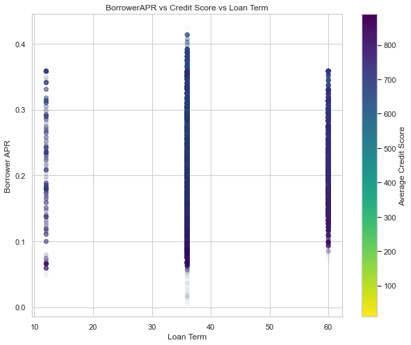

```python
#plot replation BorrowerAPR vs Credit Score vs Loan Term
plt.figure(figsize= [10, 8])
plt.scatter(data=pld, x='Term', y='BorrowerAPR', c='CreditScoreAve', cmap='viridis_r', alpha=1/40);
cbar = plt.colorbar(label='Average Credit Score')
cbar.solids.set(alpha=1)
plt.xlabel('Loan Term')
plt.ylabel('Borrower APR');
plt.title('BorrowerAPR vs Credit Score vs Loan Term');
```

### Talk about some of the relationships you observed in this part of the investigation. Were there features that strengthened each other in terms of looking at your feature(s) of interest?

Estimated Loss has a positive relationship with BorrowerAPR, Estimated Yield. That lead Credit Score would really impact the Loan Amount, Yields, and Interest Rate.

Debt to Ration has a lowest infulence on the rest of the analyzed variables

### Were there any interesting or surprising interactions between features?

At 'BorrowerAPR', 'ProsporScore' vs 'EstimatedReturn', at Prosper score level of 5,6,7,8 and 9 was linear relation we see shading in the linear which might leads to assumtion on that the borrowers with a good credit rate were able to repay the loan faster which reduce the actual interest rate return.

## Conclusion :

In the beginning of the analysis we stated few questions to be able to answer them from the data set of Prosper. There question were :

- What's income level for the borrowers?
- Does Estimated Return varies from the BorrowerAPR?
- What's the borrowers Credit Score?
- Does Credit Score and Credit Rating influence the borrowers APR?
- Does borrower Income has influence?
- What are the Credit rating for Homeowner borrowers?
- Does Lenders prefer borrowers with better Prosper Score ?
- What's the relation between
  - Current and Completed Loans vs. Borrower Rate
  - Homeowner vs. Credit Rating
  - Income Range vs. Borrowers Rating
  - Credit Grades vs. BorrowerRate
  - Income Range vs. CreditScoreAve
  - Prosper Score vs. Credit Score Ave
  - Credit Rating vs. Income Range
  - Average Credit Score vs. BorrowerAPR
  - 'BorrowerAPR', 'ProsporScore' vs 'EstimatedReturn'
  - Relation between Borrowers Rate and Credit Rating during the Years
  - Average Credit Score vs. Borrower APR vs. Loan Term
  - Estimated Loss vs BorrowerAPR

And we were able to state the answer to those questions visually by using Univariate analysis we were able to get sense of the dataset features. Then we did Bivariate and Mulitvariate analysis to find the relationship between the features.